# Workshop 5: Searching the Literature & Choosing Your Statistical Adventure

- Show All Code
- Hide All Code
- View Source

Research Methods and Statistics - T2 2025

Author

Aaron Bach

Published

August 31, 2025

[interactive chart not shown]

# 1 Introduction

Welcome to Workshop 5! Today we’re bridging the gap between finding quality research literature and selecting appropriate statistical methods for your group projects. This workshop is designed give you a taste of some practical skills in searching for literature, looking for quality sources, and planning out your group projects analysis.

## 1.1 What We’ll Accomplish Today

In today’s session, you’ll begin to develop two things that are fundamental to evidence-based research. First, you’ll see the art of systematic literature searching using scholarly databases, learning to efficiently locate high-quality, peer-reviewed sources that directly inform your research questions. Second, you’ll apply a structured decision-making framework to select appropriate statistical tests, ensuring your analysis approach aligns with your study design and variable types.

By the end of today, you should have confidence in being able to create literature foundation for your assignment and have clear analytical roadmap for said assignment.

## 1.2 Why This Matters

Effective literature searching isn’t just about finding *enough* sources, it’s about finding the *right* sources that genuinely advance your understanding and inform your methodology. Similarly, statistical test selection isn’t about memorising rules but about understanding the logical connections between your research design, question(s), data types, and analytical goals. These skills should serve you well beyond this course, whether you’re conducting research, critically evaluating evidence in your profession, or simply becoming a more informed consumer of scientific information.

## 1.3 Student Information & Research Focus

[interactive chart not shown]

## 1.4 Learning Objectives

By the end of this workshop, you will be able to:

- **Navigate** Google Scholar and PubMed effectively to find relevant, credible sources
- **Evaluate** research quality and relevance using specific criteria
- **Map** research questions to appropriate statistical tests using the decision tree framework
- **Justify** statistical analysis choices based on variable types and research design
- **Integrate** literature findings with statistical planning for your group project

# 2 Part 1: Literature Search Strategies

## 2.1 Focus Databases: Scholar and PubMed

Today we’ll concentrate on mastering two essential databases that will serve you throughout your academic journey:

[**Google Scholar**](https://scholar.google.com/) excels at providing broad coverage across disciplines and often finds freely accessible versions of papers.

[**PubMed**](https://pubmed.ncbi.nlm.nih.gov/) is the gold standard for health and life sciences research, offering sophisticated search capabilities and access to high-quality, peer-reviewed medical literature. Its controlled vocabulary ([**MeSH terms**](https://www.ncbi.nlm.nih.gov/mesh/)) helps ensure comprehensive and precise searches.

While **SPORTDiscus** remains an excellent resource for exercise science research (and you’re encouraged to explore it independently if needed). Accessible through the [**Griffith Library**](https://libraryguides.griffith.edu.au/az/sportdiscus-with-full-text-via-ebscohost)

Today’s structured activities will focus on Scholar and PubMed to ensure you master these foundational platforms.

## 2.2 Searching: Visual Guide

This Venn diagram helps visualise how **AND**, **OR**, and **NOT** influence search results across databases.

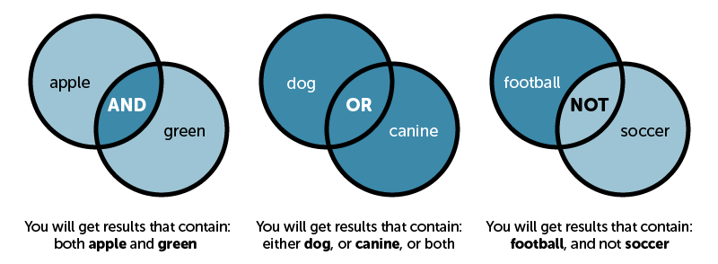

Figure 1: Boolean Searching Venn Diagram

**Search Strategy Tips**

- Use **quotation marks** for exact phrases: `"working memory"`
- **Combine concepts** with AND: `exercise AND memory AND performance`
- Use **OR for synonyms**: `"physical activity" OR exercise OR fitness`
- **Filter by date** to find recent studies
- **Check citation counts** as one very basic quality indicator

**For PubMed specifically:**

- Explore **MeSH terms** (Medical Subject Headings) for precision
- You can use **field tags** like [Title/Abstract] to focus searches (unlikely to be required for this course)

## 2.3 Task 1.1: Systematic Database Search

### 2.3.1 Step 1: Record Your Search Results

Fill in your search terms and results for each database:

[interactive chart not shown]

**Critical Warning: Use of LLM Tools in Literature Searching**

**Important Note:** Use of LLM tools (e.g., ChatGPT, Gemini, Claude, etc.) are prone to **hallucinating references, links, and interpretation of studies**. These tools:

- Often generate fake citations that don’t exist
- Provide incorrect URLs or DOIs (a DOI is a document identification link)
- Misinterpret or ignore study findings and statistical results
- Fail to distinguish between high-quality and low-quality studies
- Work primarily off keywords with little to no critical analysis of research quality
- Cannot verify the actual existence or content of papers
- Do not have access to much of the published literature, especially recent (<12months) literature not within their models

**Always verify any references or study information from LLMs by:** 1. Checking the actual database for the paper’s existence 2. Reading the original source yourself 3. Confirming URLs and DOIs work 4. Evaluating study quality using established criteria

If you do this you will see how bad they are and why at this stage, LLMs should **NEVER** be your primary or sole source for literature searching.

## 2.4 Task 1.2: Source Quality Evaluation

I have made up a pretty simple (and not comprehensive) scoring system for first timers evaluating the literature. Here you’ll evaluate three sources using the **Quality Scorecard**. For each criterion, use the **1-2-3 scale** where higher numbers = better quality.

**Quality Evaluation Guide**

**Relevance** (Does it match your research question?)

- **1 = Poor**: Off-topic, barely related to your question
- **2 = Okay**: Somewhat related, touches on your topic
- **3 = Excellent**: Directly addresses your research question

**Recency** (Is it current enough?)

- **1 = Poor**: >10 years old, likely outdated
- **2 = Okay**: 5-10 years old, still relevant
- **3 = Excellent**: <5 years old, very current

**Credibility** (Can you trust the source?)

- **1 = Poor**: Blog, Wikipedia, unknown journal
- **2 = Okay**: Professional website, conference paper
- **3 = Excellent**: Reputable peer-reviewed journal/publisher (you can check by typing into Google search the *journal name + “scimago”* [a journal ranking website]. Ideally we want *Q1 journals*)

**Methods** (Are they doing good science?)

- **1 = Poor**: No methods section, vague descriptions, not repeatable
- **2 = Okay**: Basic methods described, only cited a few of their techniques (data collection and analysis)
- **3 = Excellent**: Detailed, clear, appropriate methods, repeatable and heavily citing techniques

**Sample** (Did they study enough of people? Are the people in the sample relevant for the research question?)

- **1 = Poor**: Very small sample (exercise science n<15, pharmacy n<30), and/or people not representing the research question
- **2 = Okay**: Moderate sample size (exercise science n~30, pharmacy n~60) and/or people likely representative
- **3 = Excellent**: Large sample (exercise science n>50, pharmacy n>100) and/or people obviously representative

### 2.4.1 Source 1 Quality Scorecard

[interactive chart not shown]

### 2.4.2 Source 2 Quality Scorecard

[interactive chart not shown]

### 2.4.3 Source 3 Quality Scorecard

[interactive chart not shown]

## 2.5 Task 1.3: Strategic Reading

Extract key information from your best source:

[interactive chart not shown]

# 3 Part 2: Your Statistical Adventure

## 3.1 The Statistical Decision Framework

Before jumping into test selection, you need to systematically work through key factors that will determine your analytical approach.

[interactive chart not shown]

## 3.2 Task 2.1: Define Your Variables & Design

Select your research question to load, or manually define your study characteristics:

[interactive chart not shown]

## 3.3 Task 2.2: Statistical Test Calculator

[interactive chart not shown]

### 3.3.1 Analysis Decision Logic Reference

[interactive chart not shown]

# 4 Part 3: Project Integration & Planning

## 4.1 Quality Control Checklist

Check off completed items and note any additional learnings:

[interactive chart not shown]

# 5 Save Your Work

Click the buttons below to download all your responses as a clean HTML summary:

[interactive chart not shown]

**Before You Leave**

1. Save your work using the button above
2. Email the saved file to yourself and/or your group members
3. The file can be opened in any browser to review your responses

*Document generated on 2025-08-31 using R version 4.2.2 and Quarto*